# QCC Data Warehouse and OBIEE Dashboards

Elisabeth Lackner and Patrick Wynne

January 26, 2018

## Overview

- Goal: governed self discovery
- Data warehousing
- Data governance
- OBIEE reporting and analyses

## Data Visualization/Presentation Spectrum

- Data visualization falls on a *spectrum from exploratory to narrative*, typically corresponding to the beginning and end of the data analysis process respectively
- IR writes flexible domain specific reports to crowdsource the *exploratory data analysis* (EDA) process across the campus community
- IR then works with constituents to turn EDA into compelling and sound narratives

## How

- Collaboration between IR, IT, and senior administration
- Create data warehouse from CUNY First Reporting Instance using Oracle tools (SQL Developer, Administration Tool, Business Intelligence Enterprise Edition)
- Create data governance workflow for OBIEE using Data Cookbook
- Create reports and give read access to relevant parties

## Data Flow

[figure not shown]

## Data Warehouse

- Scheduled queries from the reporting instance are the primary data sources, but the *extract transform load* (ETL) is easily extendable to other data sources
- The key feature is *change data capture*. Everyday the ETL compares today’s data to yesterday’s and records all changes. This allows us to recreate the warehouse’s state on any given day.
- Prespecified snapshot tables are created e.g. current offset, latest data, 10 days before the start of the semester etc.

## Data Governance

- A greenfield data warehouse project leads naturally to collaborative data governance
- Replace legacy naming conventions (UNT_TAKEN_PRGRSS, UNT_TAKEN_GPA, UNT_TAKEN_PA, UNT_TAKEN_PA_GPA?) with intuitive alternatives
- Establish a data dictionary workflow whereby IR/IT send data definitions and calculations to responsible departments for approval via Data Cookbook

## OBIEE Example - New Student Dashboard

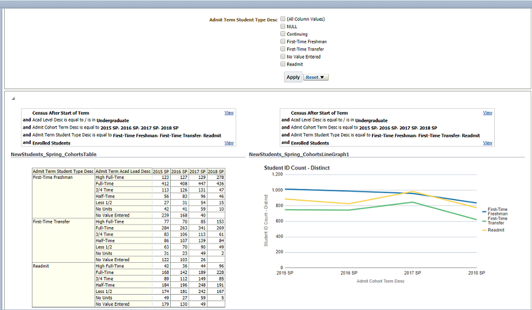

## OBIEE Example - New Student Dashboard

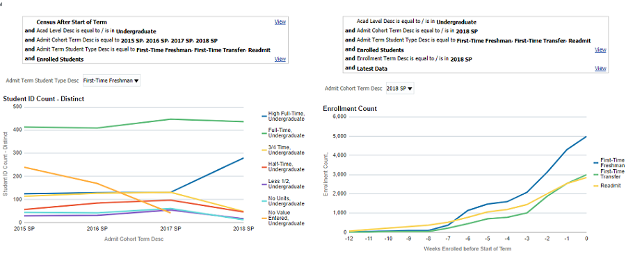

## OBIEE - Course Section Management

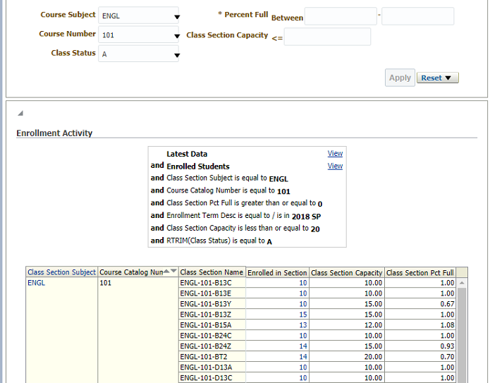

## OBIEE - Course Section Management

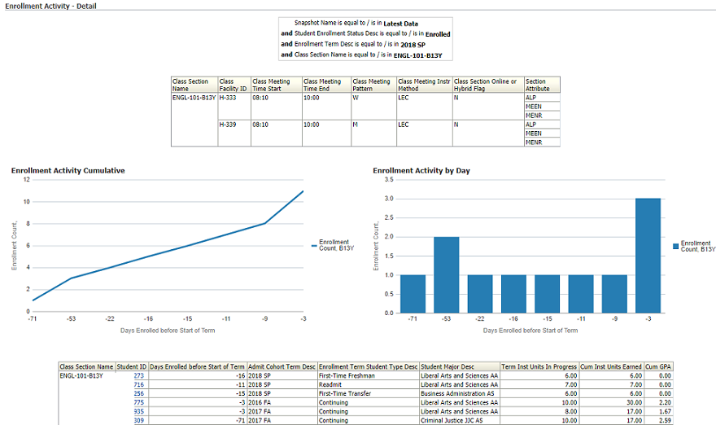

## OBIEE - Course Section Management

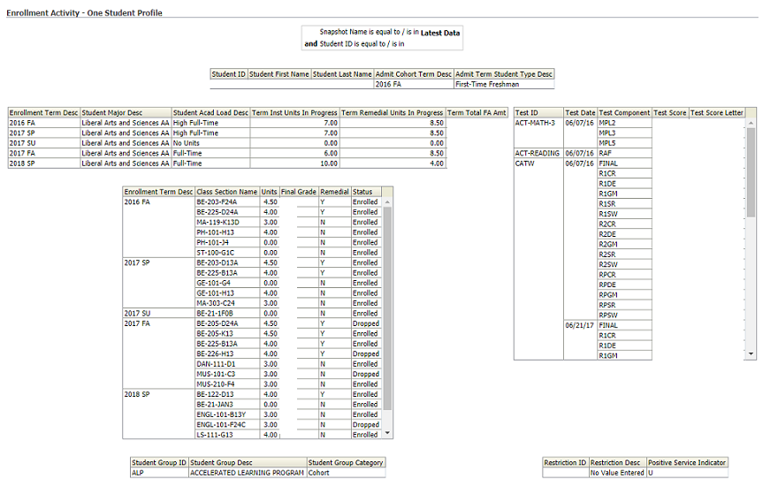

## OBIEE Course Outcomes

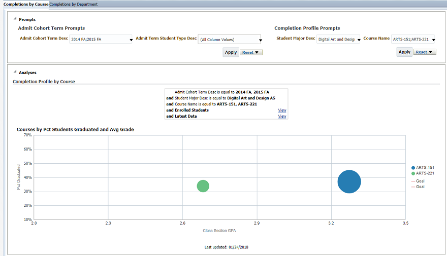

## Questions?

Elisabeth Lackner  
Director of Institutional Research and Assessment  
ELackner@qcc.cuny.edu  
718-631-6279  
Patrick Wynne  
Institutional Research Specialist  
PWnne@qcc.cuny.edu  
718-631-6279